# Qiime2 Moving Pictures tutorial

ANSC595

2/16/2021

## Step #1 Logging into the cluster

#### On a mac

Open Terminal and type:

```
$ ssh user.name@bell.rcac.purdue.edu

$ ssh user.name@scholar.rcac.purdue.edu
```

And enter your password.

#### On a PC

You can either download and install Putty (an ssh client) and enter

```
bell.rcac.purdue.edu
```

in the Host name space. Make sure ssh is selected

## You should now be on the cluster.

It would be best to start an interactive session at this point.

For bell:

```
$ slist                         #First check the availability of the microbiome nodes
$ squeue -A microbiome       #Who is using how many resources?
$ sinteractive -A microbiome -t 2:30:00 -n12
```

## Getting set up

You will need the necessary modules to run qiime:

```
$ module load bioinfo
$ module load Qiime/2-2020.11
$ module list
```

#### Moving Pictures tutorial

Now set up your directory structure

```
$ cd $RCAC_SCRATCH
$ mkdir qiime
$ mkdir qiime/qiime2-moving-pictures-tutorial
$ cd qiime/qiime2-moving-pictures-tutorial
$ mkdir emp-single-end-sequences/
```

The moving pictures tutorial uses the data from a 2011 paper (https://www.ncbi.nlm.nih.gov/pubmed/21624126) that tracks the microbiome of four body sites from two people over 396 timepoints. The study is older, so these are single-end read sequences. They used both illumina and 454 sequencing.

This tutorial has many of the steps that we entered into mothur packaged into only a few steps:

1. Get the metadata and sequence data
2. Make a qiime artifact
3. Demultiplex (demux)
4. Sequence quality control and feature table construction (Denoising)
5. FeatureTable and FeatureData summaries (OTU table)
6. Generate a tree for phylogenetic diversity analyses
7. Alpha and beta diversity analysis
8. Taxonomic analysis and stats

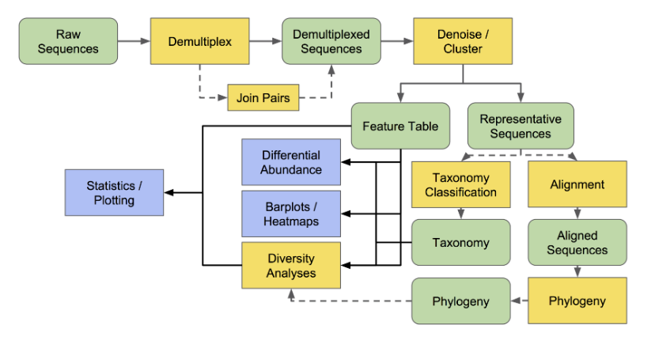

For the moving pictures tutorial, this is all fairly straight forward:

| Process | Input | Output |
| --- | --- | --- |
| 1. Get the metadata and sequence data | NA | metadata and sequences |
| 2. Make a qiime artifact | metadata and sequences | emp-single-end-sequences.qza |
| 3. demux | emp-single-end-sequences.qza | demux.qza |
| 4. Denoising | demux.qza | table.qza |
| 5. FeatureTable | table.qza | table.qzv and rep-seqs.qzv |
| 6. phylogeny | rep-seqs.qza | aligned-rep-seqs.qza; masked-aligned-rep-seqs.qza; unrooted-tree.qza; rooted-tree.qza |
| 7. diversity | rooted-tree.qza and table.qza | core-metrics-results (many) |
| 8. Taxonomic analysis | table.qza and (many) | (many) |

Now you can follow the tutorial available at

https://docs.qiime2.org/2020.11/tutorials/moving-pictures/

### How do I stop my session

When you are done for the day, and you have HAD ENOUGH, it would be responsible to stop your interactive session. If you just close your terminal or putty window, the interactive session will continue to run for no reason until the time you asked for expires and then will be automatically quit. So it would be responsible to stop the interactive session when your done.

```
#The following stops a job, like an interactive session.
#You have to enter your job id number below where indicated
$ scancel <job-id>

#for example
$ scancel 1388451
```

To get your job id, using the squeue command would be a good idea. For example:

```
$ squeue -A microbiome
```

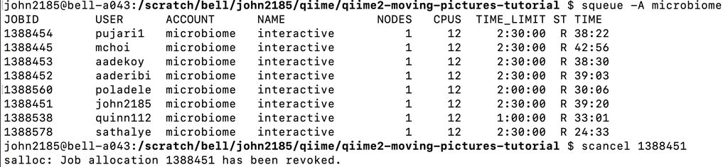

```
# to disconnect from your ssh to the bell cluster
$ exit
```

now you would be on your own computer and not connected to the cluster.